# Trametinib Prediction Example

```r
library(caret)
library(tidyverse)
library(ggplot2)
library(ggpubr)
```

## Import Data

KSEA and Drug response data is inported using thr read.csv function. KSEA data is then scaled by the caret::preprocess function and then merged with Drug response data to make the ML input dataframe.

```r
#Load Files
Kinase_Activity <- read.csv("Kinase_activity_PDT.csv",h=T, row.names = "ids") #(loads kinase activity dataset)
Drug_Response<- read.csv("Drug_response.csv",h=T, row.names = "ids") #(loads drug response dataset)

#Centre and Scale Kinase Activity Dataset
ML_test_no <- caret::preProcess(Kinase_Activity, method = c("zv","center", "scale"))
Kinase_Activity_Processed <- predict(ML_test_no, Kinase_Activity)

#Link Kinase Activity data to Drug Response to Trametinib
Trametinib_Response<- Drug_Response[,"MEKi.response.1microM", drop = F]
colnames(Trametinib_Response)<-("Trametinib_1uM")

Kinase_Activity_Trametinib<-merge(x = Kinase_Activity_Processed,
                                  y = Trametinib_Response,
                                  by = "row.names") %>% data.frame(row.names = "Row.names")
```

#Create Data Partitions

Train and test values are split using the caret::createDataPartition function. This creates an an index value which is used do to select sample rows for train and test datasets.

```r
#Create Partition of Train Set and Test Set
set.seed(41) #MEKi
index <- createDataPartition(Kinase_Activity_Trametinib$Trametinib_1uM, p=0.70, list=FALSE)
trainSet <- Kinase_Activity_Trametinib[index,]
testSet <- Kinase_Activity_Trametinib[-index,]
```

# Select features using Partial Least Squares(PLS)

The model is then trained by the train function with a “RMSE” model error readout.

Important variables are drawn from the PLS_fitmodel by using the varImp function and those with an importance value less than 50 are removed.

```r
#Generate PLS Model for Feature Selection
fit_control <- trainControl(
  method = "LOOCV",
  number = 10)

PLS_fit <- train(Trametinib_1uM ~ .,
                data = trainSet,
                metric = "RMSE",
                method = "pls",
                tuneLength = 7,
                maximize=TRUE,
                trControl = fit_control,
                linout = TRUE)

#Select Features with Importance > 50 in PLS Model
Importance <- varImp(PLS_fit)[["importance"]]
Important_variables <- subset(Importance, Overall>50)
Important_variables$kinase<-rownames(Important_variables)
```

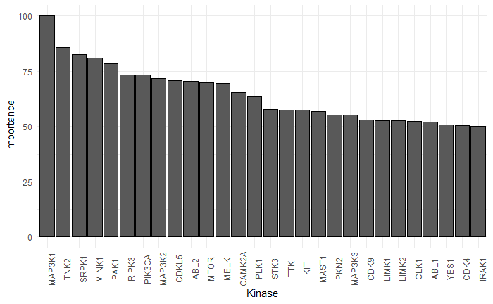

# Build random forest (RF) models using only important variables

Filter RF input data to only Important variables. The models using the “rf” algorithm and a “RMSE” error readout.

```r
#Filter Features with Importance > 50 in PLS Model in Train and Test set for RF Model
Important_variables <- c(Important_variables$kinase, "Trametinib_1uM")
trainSet<- trainSet[,Important_variables]
testSet<- testSet[,Important_variables]

#Generate RF Model
fit_control <- trainControl(
  method = "LOOCV",
  number = 20)

rf_fit <- train(Trametinib_1uM ~ .,
                data = trainSet,
                metric = "RMSE",
                method = "rf",
                tuneLength = 7,
                maximize=TRUE,
                trControl = fit_control,
                ntree=1000,
                linout = TRUE)
```

## Summary of RF model Generated

```
Random Forest

28 samples
28 predictors

No pre-processing
Resampling: Leave-One-Out Cross-Validation
Summary of sample sizes: 27, 27, 27, 27, 27, 27, ...
Resampling results across tuning parameters:

  mtry  RMSE       Rsquared   MAE
   2    0.2079644  0.1783117  0.1708275
   6    0.2076374  0.1742468  0.1698943
  10    0.2072426  0.1771172  0.1696427
  15    0.2094164  0.1624786  0.1730930
  19    0.2083479  0.1714607  0.1727995
  23    0.2065428  0.1854309  0.1712039
  28    0.2078657  0.1763445  0.1719752

RMSE was used to select the optimal model using the largest value.
The final value used for the model was mtry = 15.

Call:
 randomForest(x = x, y = y, ntree = 1000, mtry = param$mtry, linout = TRUE)
               Type of random forest: regression
                     Number of trees: 1000
No. of variables tried at each split: 15

          Mean of squared residuals: 0.04303627
                    % Var explained: 17.49
```

|  | mtry | RMSE | Rsquared | MAE |
| --- | --- | --- | --- | --- |
| 1 | 2 | 0.2079644 | 0.1783117 | 0.1708275 |
| 2 | 6 | 0.2076374 | 0.1742468 | 0.1698943 |
| 3 | 10 | 0.2072426 | 0.1771172 | 0.1696427 |
| 4 | 15 | 0.2094164 | 0.1624786 | 0.1730930 |
| 5 | 19 | 0.2083479 | 0.1714607 | 0.1727995 |
| 6 | 23 | 0.2065428 | 0.1854309 | 0.1712039 |
| 7 | 28 | 0.2078657 | 0.1763445 | 0.1719752 |

# Model Evaluation

Predictions of model performance in test data is used to evaluate model accuracy.

```r
#Generate Datasets of Predicted and Measured Values for Train and Test Sets


trainplot <- merge(x = predict(rf_fit, trainSet) ,
                   y = trainSet[, "Trametinib_1uM", drop = F],
                   by = "row.names")

colnames(trainplot) <- c("ids", "Predicted", "Measured")

testplot <- merge(x = predict(rf_fit, testSet) ,
                  y = testSet[, "Trametinib_1uM", drop = F],
                  by = "row.names")

colnames(testplot) <- c("ids", "Predicted", "Measured")

#Calculate RMSE for Train and Test Sets
Train_RMSE<-RMSE(trainplot$Predicted, trainplot$Measured ,na.rm = T)
Test_RMSE<-RMSE(testplot$Predicted, testplot$Measured, na.rm = T)

print(paste("Train RMSE:",round(Train_RMSE, 2)))
```

```
[1] "Train RMSE: 0.08"
```

```r
print(paste("Test RMSE", round(Test_RMSE,2)))
```

```
[1] "Test RMSE 0.14"
```

## Dotplots of RF model accuracy

[figure not shown]

# Identify important feature of the RF model

Draw feature importance values from the model

```r
Importance <- varImp(rf_fit)[["importance"]]
Important_variables <- subset(Importance, Overall>20)
Important_variables$kinase<-rownames(Important_variables)
```

## Barplot of most important features

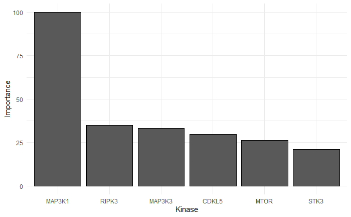

# Ensamble generation of models

Create a multicore for loop to generate 50 rf models

```r
#import multicore processing packages
library(doParallel)
library(foreach)

#Set up cores
doParallel::registerDoParallel(cores=4)

#random list of seeds to iterate through
seeds<- runif(n=50, min=1, max=500) %>% round(0)
i <- seeds[1]
#begining of multicore for loop
results <- foreach(i = seeds, .combine="rbind", .packages = c("caret", "stats", "dplyr"))%dopar%{

  set.seed(i)

  #create data partitions
  index <-
    createDataPartition(Kinase_Activity_Trametinib$Trametinib_1uM,
                        p = 0.70,
                        list = FALSE)
  trainSet <- Kinase_Activity_Trametinib[index, ]
  testSet <- Kinase_Activity_Trametinib[-index, ]
  fit_control <- trainControl(method = "LOOCV",
                              number = 10)

  PLS_fit <- train(
    Trametinib_1uM ~ .,
    data = trainSet,
    metric = "RMSE",
    method = "pls",
    tuneLength = 7,
    maximize = TRUE,
    trControl = fit_control,
    linout = TRUE
  )

  #Select Features with Importance > 50 in PLS Model
  Importance <- varImp(PLS_fit)[["importance"]]
  Important_variables <- subset(Importance, Overall > 50)
  Important_variables$kinase <- rownames(Important_variables)

  #Filter Features with Importance > 50 in PLS Model in Train and Test set for RF Model
  Important_variables <-
    c(Important_variables$kinase, "Trametinib_1uM")
  trainSet <- trainSet[, Important_variables]
  testSet <- testSet[, Important_variables]

  #Generate RF Model
  fit_control <- trainControl(## 10-fold CV
    method = "LOOCV",
    number = 20)

  rf_fit <- train(
    Trametinib_1uM ~ .,
    data = trainSet,
    metric = "RMSE",
    method = "rf",
    tuneLength = 7,
    maximize = TRUE,
    trControl = fit_control,
    ntree = 1000,
    linout = TRUE
  )

  trainplot <- merge(x = predict(rf_fit, trainSet) ,
                     y = trainSet[, "Trametinib_1uM", drop = F],
                     by = "row.names")

  colnames(trainplot) <- c("ids", "Predicted", "Measured")

  testplot <- merge(x = predict(rf_fit, testSet) ,
                    y = testSet[, "Trametinib_1uM", drop = F],
                    by = "row.names")

  colnames(testplot) <- c("ids", "Predicted", "Measured")

  #Calculate RMSE for Train and Test Sets
  Train_RMSE <-
    RMSE(trainplot$Predicted, trainplot$Measured , na.rm = T)
  Test_RMSE <- RMSE(testplot$Predicted, testplot$Measured, na.rm = T)

  #Calculate Spearman Rank Correlation Coefficients
  Train_p <-
    cor.test(trainplot$Predicted, trainplot$Measured, method = "spearman")
  Test_p <-
    cor.test(testplot$Predicted, testplot$Measured, method = "spearman")

  #Get Important features from RF model
  Importance <- varImp(rf_fit)[["importance"]]
  rf_Important_variables <- subset(Importance, Overall > 20)

  #combine results to output
  out <- data.frame(
    "seed" = i,
    "Train_RMSE"= Train_RMSE,
    "Test_RMSE"=Test_RMSE,
    "Train_p" = Train_p[[3]],
    "Test_p" = Test_p[[3]],
    "Train_coef" = Train_p[[4]],
    "Test_coef" = Test_p[[4]],
    "n_features_input" = length(Important_variables),
    "Important_features" = paste(rownames(rf_Important_variables), collapse=";"),
    "important_features_value" =  paste(rf_Important_variables$Overall, collapse=";")
  )

  return(out)
}

write.csv(results, file = "Ensamble_rf_results.csv")
```

## Summary of Features

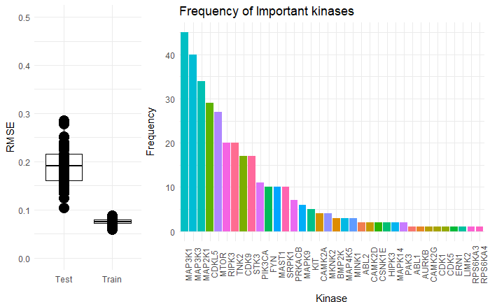

```
NA
```